# Bayesian Analysis of Pollution Effects on Mortality in Milan

2026-02-08

# 1 Libraries

```r
library(brms)
library(tidyverse)
library(lubridate)
library(bayesplot)
library(performance)
library(patchwork)
library(posterior)

theme_set(bayesplot::theme_default())
```

# 2 Data Loading

```r
setwd("C:/Users/mavip/Desktop")
d <- read.table("df_pulito.txt", header = TRUE)

summary(d[, c("tot.mort", "mean.temp", "log_SO2", "log_TSP")])
```

```
##     tot.mort       mean.temp        log_SO2          log_TSP
##  Min.   :10.00   Min.   :-6.10   Min.   :-4.605   Min.   :1.253
##  1st Qu.:27.00   1st Qu.: 7.10   1st Qu.: 3.474   1st Qu.:4.426
##  Median :31.00   Median :13.70   Median : 4.174   Median :4.765
##  Mean   :31.87   Mean   :14.03   Mean   : 4.237   Mean   :4.772
##  3rd Qu.:37.00   3rd Qu.:21.40   3rd Qu.: 5.063   3rd Qu.:5.139
##  Max.   :66.00   Max.   :31.50   Max.   : 6.719   Max.   :6.272
```

# 3 Variable Preparation

```r
d <- d %>%
  mutate(
    day.of.week = factor(day.of.week),
    holiday = factor(holiday),
    day.of.year = (day.num - 1) %% 365 + 1
  )
```

# 4 PPC Function

```r
check_model <- function(model, dat, label) {
  cat("\n=== Diagnostics for", label, "===\n\n")

  # 1. PPC: density
  p1 <- pp_check(model, type = "dens_overlay", ndraws = 50) +
    ggtitle(paste(label, "- Observed vs predicted density"))
  print(p1)

  # 2. PPC: key statistics
  p2 <- pp_check(model, type = "stat", stat = "mean") +
    ggtitle(paste(label, "- Test: Mean"))
  p3 <- pp_check(model, type = "stat", stat = "sd") +
    ggtitle(paste(label, "- Test: SD"))
  print(p2 / p3)  # stack vertically with patchwork

  # 3. Residuals
  resid <- residuals(model)[, "Estimate"]

  valid_idx <- !is.na(resid)
  resid_clean <- resid[valid_idx]
  time_clean <- dat$day.num[valid_idx]

  # Plot residuals over time
  p4 <- ggplot(data.frame(time = time_clean, resid = resid_clean),
               aes(x = time, y = resid)) +
    geom_point(alpha = 0.3) +
    geom_hline(yintercept = 0, linetype = "dashed", color = "red") +
    geom_smooth(method = "loess", se = TRUE, color = "blue") +
    labs(title = paste(label, "- Residuals over time"),
         x = "Day", y = "Residual")

  # 4. ACF
  acf_obj <- acf(resid_clean, plot = FALSE, lag.max = min(30, floor(length(resid_clean)/4)))
  n_lags <- length(acf_obj$acf) - 1

  acf_df <- data.frame(
    lag = 1:n_lags,
    acf = acf_obj$acf[-1]
  )

  ci <- 1.96/sqrt(length(resid_clean))

  p5 <- ggplot(acf_df, aes(x = lag, y = acf)) +
    geom_hline(yintercept = 0) +
    geom_segment(aes(xend = lag, yend = 0)) +
    geom_hline(yintercept = c(-ci, ci), linetype = "dashed", color = "blue") +
    labs(title = paste(label, "- Residual ACF"),
         x = "Lag (days)", y = "Autocorrelation")

  # Combine residuals and ACF
  print(p4 / p5)

  cat("\n✓ Diagnostics completed for", label, "\n\n")
}
```

# 5 Model 0: Baseline Poisson

```r
m0 <- brm(
  tot.mort ~ day.of.week + holiday +
    sin(2 * 3.141592653589793 * day.num / 365) +
    cos(2 * 3.141592653589793 * day.num / 365),
  data = d,
  family = poisson(),
  prior = c(
    prior(normal(0, 5), class = "Intercept"),
    prior(normal(0, 0.5), class = "b")
  ),
  chains = 4, cores = 4, iter = 3000, warmup = 1500,
  control = list(adapt_delta = 0.95),
  seed = 2025,
  file = NULL
)
print(summary(m0))
```

```
##  Family: poisson
##   Links: mu = log
## Formula: tot.mort ~ day.of.week + holiday + sin(2 * 3.14159265358979 * day.num/365) + cos(2 * 3.14159265358979 * day.num/365)
##    Data: d (Number of observations: 3646)
##   Draws: 4 chains, each with iter = 3000; warmup = 1500; thin = 1;
##          total post-warmup draws = 6000
##
## Regression Coefficients:
##                                     Estimate Est.Error l-95% CI u-95% CI Rhat
## Intercept                               3.38      0.02     3.34     3.42 1.00
## day.of.weekGio                          0.03      0.01     0.01     0.05 1.00
## day.of.weekLun                          0.03      0.01     0.01     0.05 1.00
## day.of.weekMar                          0.03      0.01     0.01     0.06 1.00
## day.of.weekMer                          0.02      0.01    -0.01     0.04 1.00
## day.of.weekSab                          0.00      0.01    -0.02     0.02 1.00
## day.of.weekVen                          0.02      0.01    -0.01     0.04 1.00
## holidayNofesta                          0.06      0.02     0.02     0.09 1.00
## sin2MU3.14159265358979MUday.numD365     0.09      0.00     0.09     0.10 1.00
## cos2MU3.14159265358979MUday.numD365     0.14      0.00     0.13     0.15 1.00
##                                     Bulk_ESS Tail_ESS
## Intercept                               4041     3877
## day.of.weekGio                          2545     3585
## day.of.weekLun                          2361     3254
## day.of.weekMar                          2448     3374
## day.of.weekMer                          2397     3900
## day.of.weekSab                          2363     3811
## day.of.weekVen                          2270     3244
## holidayNofesta                          5222     4158
## sin2MU3.14159265358979MUday.numD365     6689     4581
## cos2MU3.14159265358979MUday.numD365     6571     4911
##
## Draws were sampled using sampling(NUTS). For each parameter, Bulk_ESS
## and Tail_ESS are effective sample size measures, and Rhat is the potential
## scale reduction factor on split chains (at convergence, Rhat = 1).
```

```r
check_model(m0, d, label = "m0")
```

```
##
## === Diagnostics for m0 ===
```

```
## Using all posterior draws for ppc type 'stat' by default.
## Using all posterior draws for ppc type 'stat' by default.
```

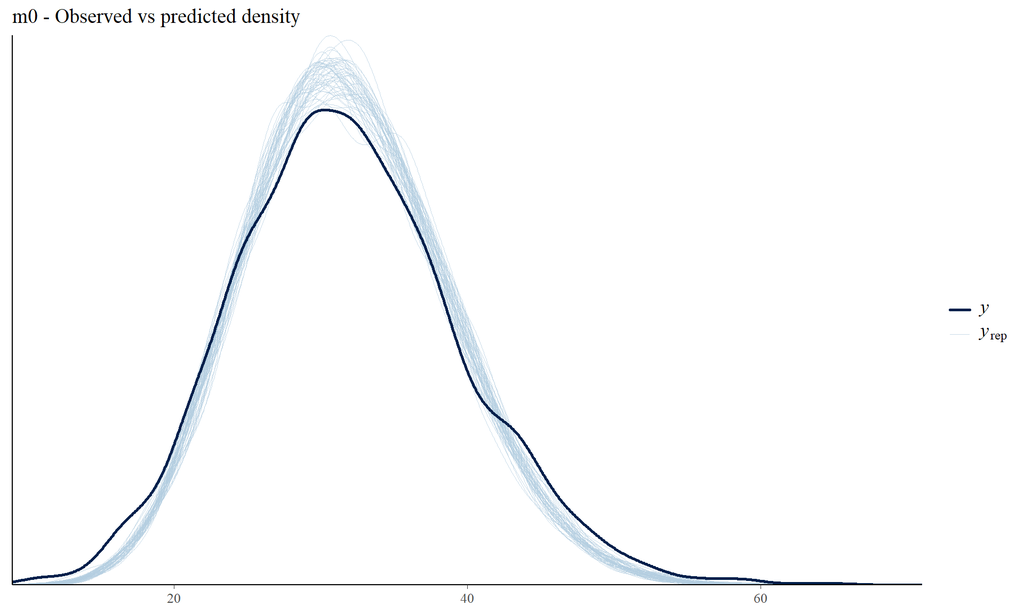

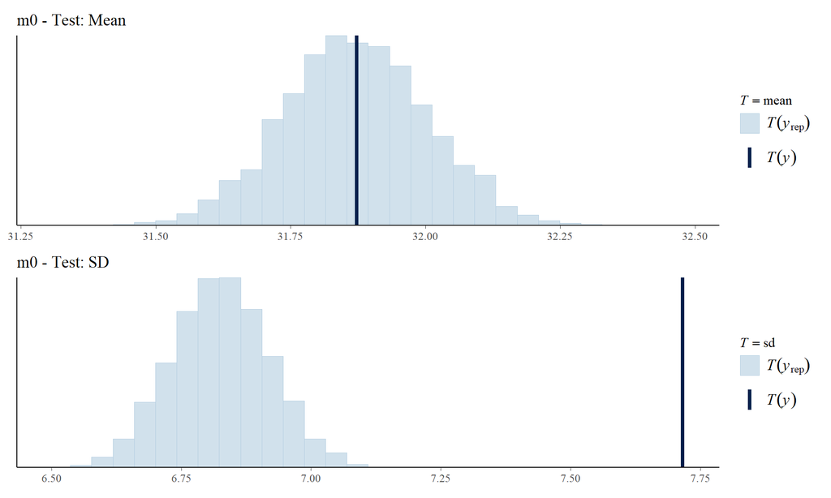

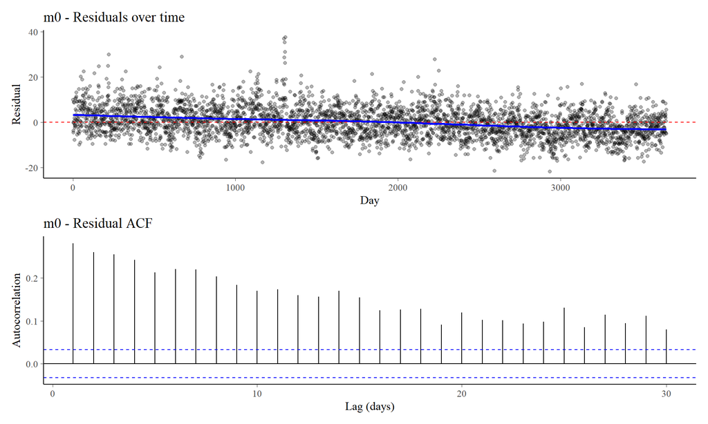

```
##
## ✓ Diagnostics completed for m0
```

```r
loo_m0 <- loo(m0)
print(loo_m0)
```

```
##
## Computed from 6000 by 3646 log-likelihood matrix.
##
##          Estimate    SE
## elpd_loo -12202.5  71.6
## p_loo        14.4   0.5
## looic     24404.9 143.1
## ------
## MCSE of elpd_loo is 0.1.
## MCSE and ESS estimates assume MCMC draws (r_eff in [0.3, 1.6]).
##
## All Pareto k estimates are good (k < 0.7).
## See help('pareto-k-diagnostic') for details.
```

```r
cat("\n=== INTERPRETATION M0 ===\n")
```

```
##
## === INTERPRETATION M0 ===
```

- This model only captures calendar patterns and very simple seasonality
- a negative-binomial seems more appropriate given the overdispersion

# 6 Model 0-NB: Baseline Negative Binomial

```r
m0_nb <- brm(
  tot.mort ~ day.of.week + holiday +
    sin(2 * 3.141592653589793 * day.num / 365) +
    cos(2 * 3.141592653589793 * day.num / 365),
  data = d,
  family = negbinomial(),
  prior = c(
    prior(normal(0, 5), class = "Intercept"),
    prior(normal(0, 0.5), class = "b"),
    prior(gamma(2, 0.1), class = "shape")
  ),
  chains = 4, cores = 4, iter = 3000, warmup = 1500,
  control = list(adapt_delta = 0.95),
  seed = 2025,
  file = NULL
)
print(summary(m0_nb))
```

```
##  Family: negbinomial
##   Links: mu = log; shape = identity
## Formula: tot.mort ~ day.of.week + holiday + sin(2 * 3.14159265358979 * day.num/365) + cos(2 * 3.14159265358979 * day.num/365)
##    Data: d (Number of observations: 3646)
##   Draws: 4 chains, each with iter = 3000; warmup = 1500; thin = 1;
##          total post-warmup draws = 6000
##
## Regression Coefficients:
##                                     Estimate Est.Error l-95% CI u-95% CI Rhat
## Intercept                               3.38      0.02     3.34     3.42 1.00
## day.of.weekGio                          0.03      0.01     0.00     0.05 1.00
## day.of.weekLun                          0.03      0.01     0.01     0.06 1.00
## day.of.weekMar                          0.04      0.01     0.01     0.06 1.00
## day.of.weekMer                          0.02      0.01    -0.01     0.04 1.00
## day.of.weekSab                          0.00      0.01    -0.02     0.03 1.00
## day.of.weekVen                          0.02      0.01    -0.01     0.04 1.00
## holidayNofesta                          0.06      0.02     0.02     0.10 1.00
## sin2MU3.14159265358979MUday.numD365     0.10      0.00     0.09     0.11 1.00
## cos2MU3.14159265358979MUday.numD365     0.14      0.00     0.13     0.15 1.00
##                                     Bulk_ESS Tail_ESS
## Intercept                               4501     4200
## day.of.weekGio                          3049     3794
## day.of.weekLun                          2941     3794
## day.of.weekMar                          3037     3838
## day.of.weekMer                          3073     3608
## day.of.weekSab                          3022     3712
## day.of.weekVen                          2914     3792
## holidayNofesta                          5093     4718
## sin2MU3.14159265358979MUday.numD365     6203     4335
## cos2MU3.14159265358979MUday.numD365     6250     4355
##
## Further Distributional Parameters:
##       Estimate Est.Error l-95% CI u-95% CI Rhat Bulk_ESS Tail_ESS
## shape    75.86      5.85    65.50    88.45 1.00     5524     4495
##
## Draws were sampled using sampling(NUTS). For each parameter, Bulk_ESS
## and Tail_ESS are effective sample size measures, and Rhat is the potential
## scale reduction factor on split chains (at convergence, Rhat = 1).
```

```r
check_model(m0_nb, d, label = "m0_nb")
```

```
##
## === Diagnostics for m0_nb ===
```

```
## Using all posterior draws for ppc type 'stat' by default.
## Using all posterior draws for ppc type 'stat' by default.
```

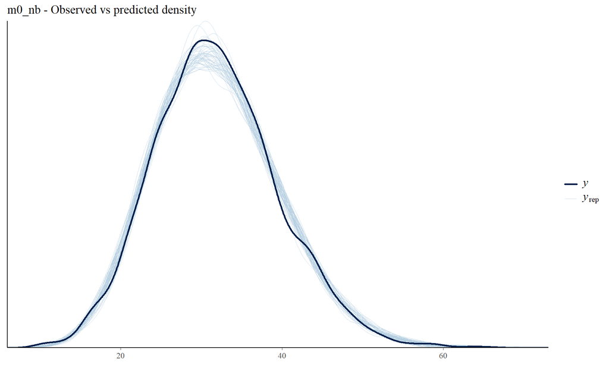

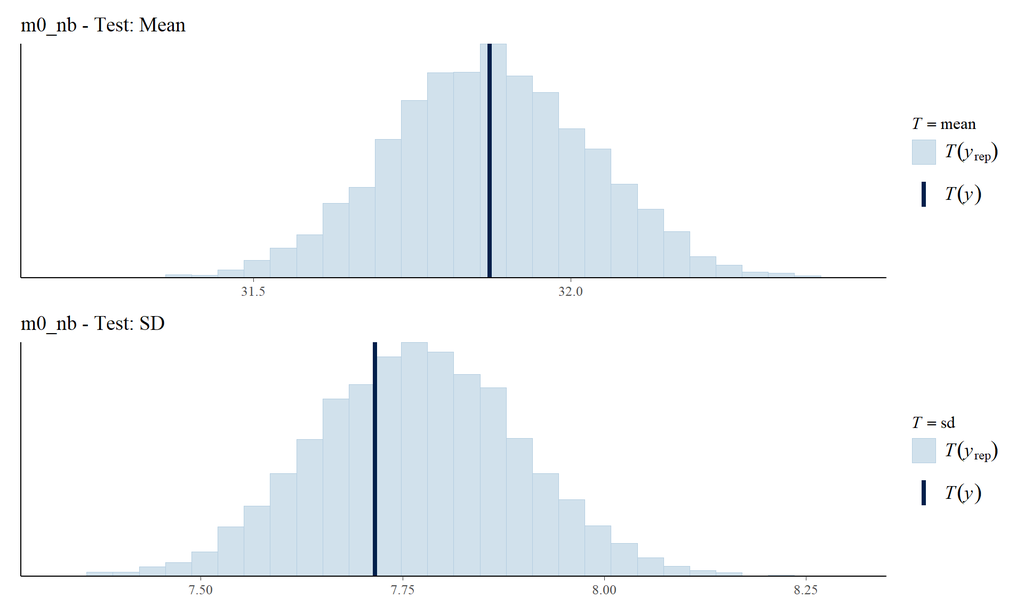

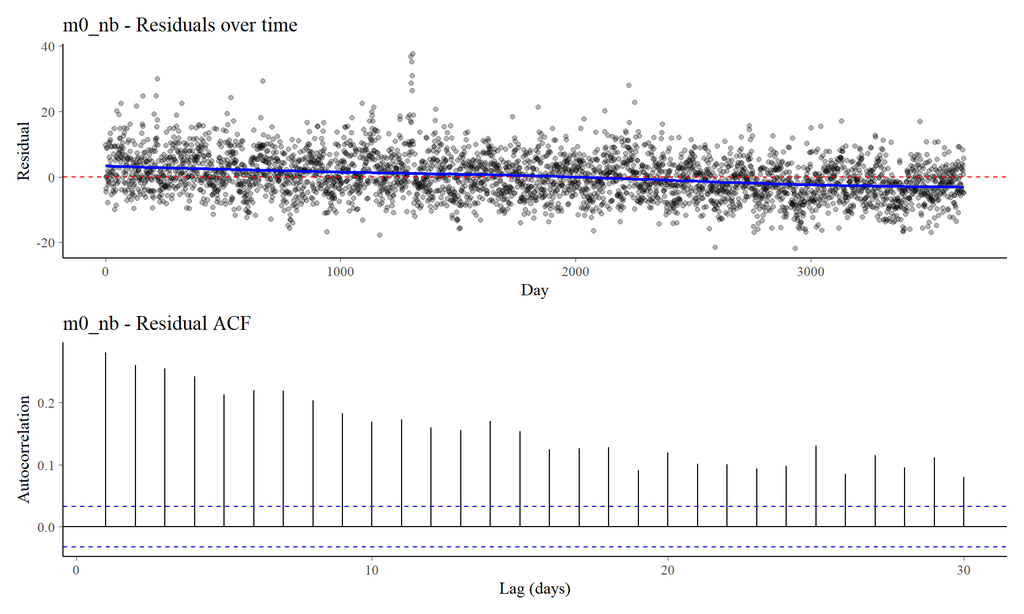

```
##
## ✓ Diagnostics completed for m0_nb
```

```r
loo_m0_nb <- loo(m0_nb)
print(loo_m0_nb)
```

```
##
## Computed from 6000 by 3646 log-likelihood matrix.
##
##          Estimate    SE
## elpd_loo -12082.3  50.5
## p_loo        11.4   0.5
## looic     24164.6 101.0
## ------
## MCSE of elpd_loo is 0.0.
## MCSE and ESS estimates assume MCMC draws (r_eff in [0.4, 1.6]).
##
## All Pareto k estimates are good (k < 0.7).
## See help('pareto-k-diagnostic') for details.
```

```r
cat("\n=== INTERPRETATION M0-NB ===\n")
```

```
##
## === INTERPRETATION M0-NB ===
```

INTERPRETATION M1 - Negative Binomial  
overdispersion is present although moderate  
elpd_loo confirms it, the negbin model is better

# 7 Temperature Model

```r
m_temp <- brm(
  tot.mort ~
    s(day.num, bs = "tp", k = 20) +
    s(day.of.year, bs = "cc", k = 20) +
    day.of.week + holiday +
    s(mean.temp, bs = "cr", k = 10),
  data = d,
  family = negbinomial(),
  prior = prior(exponential(1), class = "sds"),
  chains = 4, cores = 4, iter = 3000, warmup = 1500,
  control = list(adapt_delta = 0.95),
  file = NULL
)
print(summary(m_temp))
```

```
##  Family: negbinomial
##   Links: mu = log; shape = identity
## Formula: tot.mort ~ s(day.num, bs = "tp", k = 20) + s(day.of.year, bs = "cc", k = 20) + day.of.week + holiday + s(mean.temp, bs = "cr", k = 10)
##    Data: d (Number of observations: 3646)
##   Draws: 4 chains, each with iter = 3000; warmup = 1500; thin = 1;
##          total post-warmup draws = 6000
##
## Smoothing Spline Hyperparameters:
##                     Estimate Est.Error l-95% CI u-95% CI Rhat Bulk_ESS Tail_ESS
## sds(sday.num_1)         0.51      0.40     0.00     1.34 1.53        7       58
## sds(sday.of.year_1)     0.02      0.01     0.00     0.03 1.54        7       23
## sds(smean.temp_1)       0.04      0.02     0.02     0.09 1.54        7       14
##
## Regression Coefficients:
##                Estimate Est.Error l-95% CI u-95% CI Rhat Bulk_ESS Tail_ESS
## Intercept          3.36      0.07     3.24     3.43 1.54        7       16
## day.of.weekGio     0.04      0.02     0.00     0.07 1.58        7       12
## day.of.weekLun     0.05      0.04     0.01     0.11 1.57        7       15
## day.of.weekMar     0.05      0.03     0.01     0.11 1.54        7       35
## day.of.weekMer     0.03      0.03    -0.01     0.07 1.56        7       19
## day.of.weekSab     0.02      0.03    -0.02     0.07 1.55        7       30
## day.of.weekVen     0.04      0.04    -0.00     0.10 1.59        7       19
## holidayNofesta     0.06      0.05     0.00     0.14 1.57        7       22
## sday.num_1         0.28      0.96    -0.94     2.49 1.20       14     2037
## smean.temp_1       0.06      0.01     0.04     0.08 1.55        7       12
##
## Further Distributional Parameters:
##              Estimate       Est.Error l-95% CI         u-95% CI Rhat Bulk_ESS
## shape 363445162632.23 629557952374.26   169.27 1453780649803.64 1.52        7
##       Tail_ESS
## shape       NA
##
## Draws were sampled using sampling(NUTS). For each parameter, Bulk_ESS
## and Tail_ESS are effective sample size measures, and Rhat is the potential
## scale reduction factor on split chains (at convergence, Rhat = 1).
```

```r
check_model(m_temp, d, label = "m_temp")
```

```
##
## === Diagnostics for m_temp ===
```

```
## Using all posterior draws for ppc type 'stat' by default.
## Using all posterior draws for ppc type 'stat' by default.
```

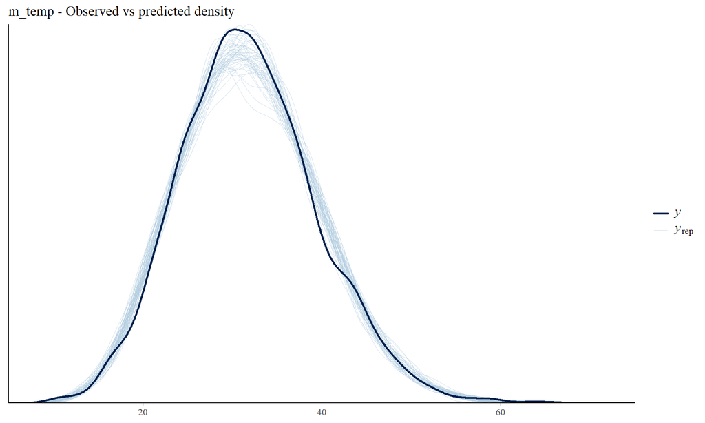

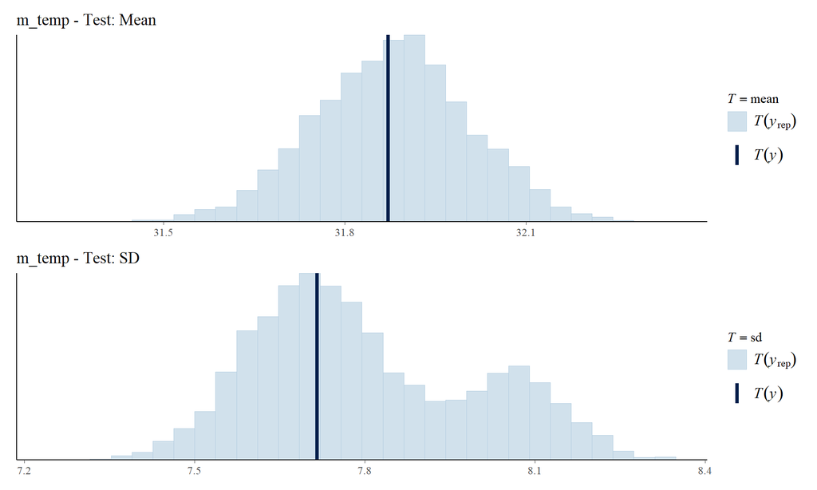

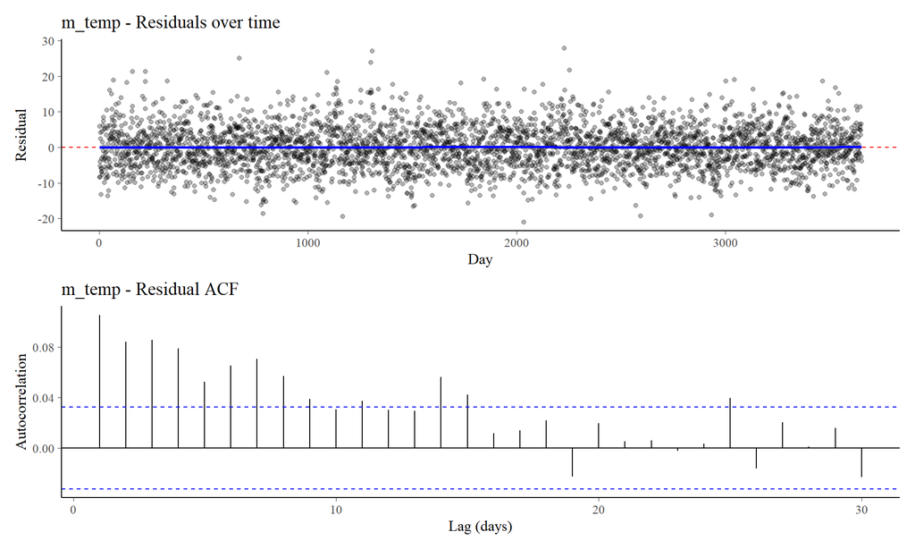

```
##
## ✓ Diagnostics completed for m_temp
```

```r
loo_m_temp <- loo(m_temp)
print(loo_m_temp)
```

```
##
## Computed from 6000 by 3646 log-likelihood matrix.
##
##          Estimate   SE
## elpd_loo -11799.3 49.8
## p_loo       129.8  8.1
## looic     23598.6 99.5
## ------
## MCSE of elpd_loo is NA.
## MCSE and ESS estimates assume MCMC draws (r_eff in [0.0, 1.4]).
##
## Pareto k diagnostic values:
##                          Count Pct.    Min. ESS
## (-Inf, 0.7]   (good)     2958  81.1%   1
##    (0.7, 1]   (bad)        57   1.6%   <NA>
##    (1, Inf)   (very bad)  631  17.3%   <NA>
## See help('pareto-k-diagnostic') for details.
```

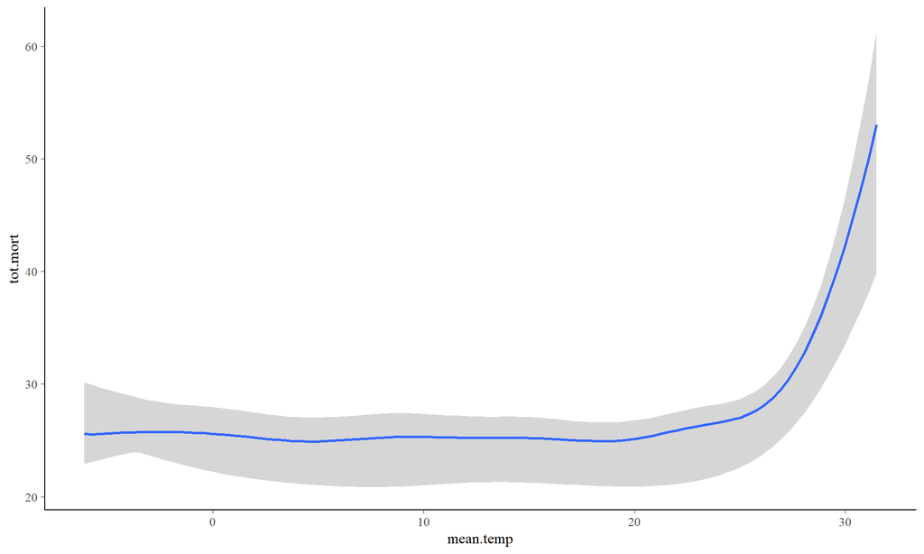

```r
plot(conditional_effects(m_temp, "mean.temp"), points = FALSE)
```

```r
cat("\n=== INTERPRETATION M-TEMP ===\n")
```

```
##
## === INTERPRETATION M-TEMP ===
```

Interpretation M2 - Temperature

# 8 Pollution Linear Model

```r
m_poll_linear <- brm(
  tot.mort ~
    s(day.num, bs = "tp", k = 20) +
    s(day.of.year, bs = "cc", k = 20) +
    day.of.week + holiday +
    s(mean.temp, bs = "cr", k = 10) +
    log_SO2 + log_TSP,
  data = d,
  family = negbinomial(),
  prior = c(
    prior(normal(0, 0.3), class = "b", coef = "log_SO2"),
    prior(normal(0, 0.3), class = "b", coef = "log_TSP"),
    prior(exponential(1), class = "sds")
  ),
  chains = 4, cores = 4, iter = 3500, warmup = 1750,
  control = list(adapt_delta = 0.97),
  file = NULL
)
print(summary(m_poll_linear))
```

```
##  Family: negbinomial
##   Links: mu = log; shape = identity
## Formula: tot.mort ~ s(day.num, bs = "tp", k = 20) + s(day.of.year, bs = "cc", k = 20) + day.of.week + holiday + s(mean.temp, bs = "cr", k = 10) + log_SO2 + log_TSP
##    Data: d (Number of observations: 3646)
##   Draws: 4 chains, each with iter = 3500; warmup = 1750; thin = 1;
##          total post-warmup draws = 7000
##
## Smoothing Spline Hyperparameters:
##                     Estimate Est.Error l-95% CI u-95% CI Rhat Bulk_ESS Tail_ESS
## sds(sday.num_1)         0.76      0.32     0.29     1.49 1.00     1329     1786
## sds(sday.of.year_1)     0.02      0.01     0.01     0.03 1.00      993     2066
## sds(smean.temp_1)       0.05      0.02     0.03     0.10 1.00     1403     2632
##
## Regression Coefficients:
##                Estimate Est.Error l-95% CI u-95% CI Rhat Bulk_ESS Tail_ESS
## Intercept          3.32      0.04     3.24     3.41 1.00     7962     5470
## day.of.weekGio     0.02      0.01    -0.00     0.05 1.00     3625     4289
## day.of.weekLun     0.03      0.01     0.00     0.05 1.00     3343     4527
## day.of.weekMar     0.03      0.01     0.01     0.06 1.00     3538     5104
## day.of.weekMer     0.01      0.01    -0.01     0.03 1.00     3396     4909
## day.of.weekSab     0.00      0.01    -0.02     0.02 1.00     3745     4861
## day.of.weekVen     0.01      0.01    -0.01     0.04 1.00     3751     5203
## holidayNofesta     0.04      0.02    -0.00     0.08 1.00     8124     5356
## log_SO2           -0.00      0.01    -0.02     0.01 1.00     5496     5633
## log_TSP            0.02      0.01     0.00     0.04 1.00     5944     4946
## sday.num_1         0.89      1.03    -0.93     3.17 1.00     2152     3280
## smean.temp_1       0.06      0.01     0.04     0.08 1.00     5404     5142
##
## Further Distributional Parameters:
##       Estimate Est.Error l-95% CI u-95% CI Rhat Bulk_ESS Tail_ESS
## shape   243.78     53.04   169.51   373.66 1.00     6341     3552
##
## Draws were sampled using sampling(NUTS). For each parameter, Bulk_ESS
## and Tail_ESS are effective sample size measures, and Rhat is the potential
## scale reduction factor on split chains (at convergence, Rhat = 1).
```

```r
check_model(m_poll_linear, d, label = "m_poll_linear")
```

```
##
## === Diagnostics for m_poll_linear ===
```

```
## Using all posterior draws for ppc type 'stat' by default.
## Using all posterior draws for ppc type 'stat' by default.
```

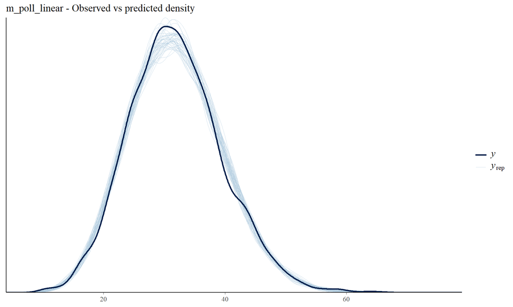

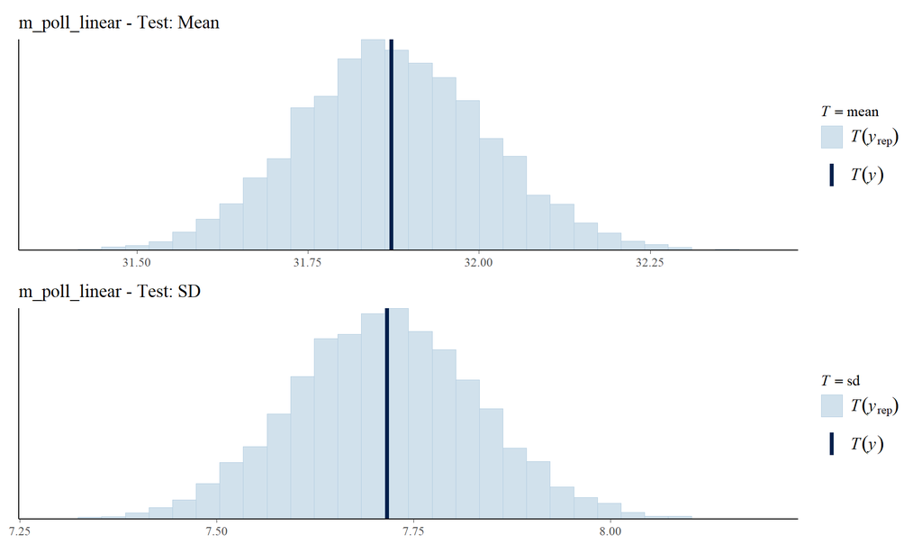

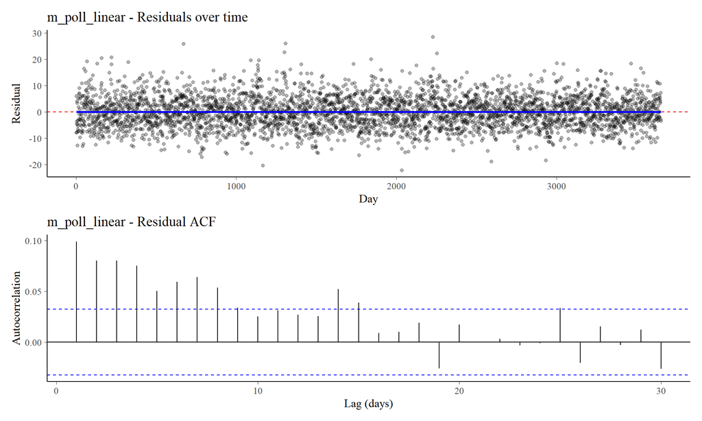

```
##
## ✓ Diagnostics completed for m_poll_linear
```

```r
loo_m_poll_linear <- loo(m_poll_linear)
print(loo_m_poll_linear)
```

```
##
## Computed from 7000 by 3646 log-likelihood matrix.
##
##          Estimate   SE
## elpd_loo -11701.3 45.2
## p_loo        45.5  1.4
## looic     23402.5 90.5
## ------
## MCSE of elpd_loo is 0.1.
## MCSE and ESS estimates assume MCMC draws (r_eff in [0.5, 1.5]).
##
## All Pareto k estimates are good (k < 0.7).
## See help('pareto-k-diagnostic') for details.
```

```r
cat("\n=== INTERPRETATION M-POLL-LINEAR ===\n")
```

```
##
## === INTERPRETATION M-POLL-LINEAR ===
```

Interpretation - Pollutants  
the addition of SO2 pollutant does not seem to have relevant effects

the effect of TSP seems to be of little relevance

# 9 Full Model

```r
m_full <- brm(
  tot.mort ~
    s(day.num, bs = "tp", k = 20) +
    s(day.of.year, bs = "cc", k = 20) +
    day.of.week + holiday +
    s(mean.temp, bs = "cr", k = 10) +
    s(log_SO2, bs = "cr", k = 6) +
    s(log_TSP, bs = "cr", k = 6),
  data = d,
  family = negbinomial(),
  prior = c(
    prior(exponential(1.5), class = "sds"),
    prior(normal(0, 0.5), class = "b")
  ),
  chains = 4, cores = 4, iter = 5000, warmup = 2500,
  control = list(adapt_delta = 0.99, max_treedepth = 13),
  seed = 2025,
  file = NULL
)
print(summary(m_full))
```

```
##  Family: negbinomial
##   Links: mu = log; shape = identity
## Formula: tot.mort ~ s(day.num, bs = "tp", k = 20) + s(day.of.year, bs = "cc", k = 20) + day.of.week + holiday + s(mean.temp, bs = "cr", k = 10) + s(log_SO2, bs = "cr", k = 6) + s(log_TSP, bs = "cr", k = 6)
##    Data: d (Number of observations: 3646)
##   Draws: 4 chains, each with iter = 5000; warmup = 2500; thin = 1;
##          total post-warmup draws = 10000
##
## Smoothing Spline Hyperparameters:
##                     Estimate Est.Error l-95% CI u-95% CI Rhat Bulk_ESS Tail_ESS
## sds(sday.num_1)         0.58      0.24     0.22     1.15 1.00     1944     2794
## sds(sday.of.year_1)     0.02      0.01     0.01     0.03 1.00     1596     3294
## sds(smean.temp_1)       0.06      0.02     0.03     0.11 1.00     1680     3203
## sds(slog_SO2_1)         0.03      0.03     0.00     0.10 1.00     3061     4514
## sds(slog_TSP_1)         0.02      0.02     0.00     0.06 1.00     3438     4707
##
## Regression Coefficients:
##                Estimate Est.Error l-95% CI u-95% CI Rhat Bulk_ESS Tail_ESS
## Intercept          3.40      0.02     3.36     3.44 1.00     9375     7512
## day.of.weekGio     0.02      0.01     0.00     0.05 1.00     4786     6379
## day.of.weekLun     0.03      0.01     0.00     0.05 1.00     5298     7007
## day.of.weekMar     0.03      0.01     0.01     0.06 1.00     4934     6452
## day.of.weekMer     0.01      0.01    -0.01     0.04 1.00     5165     7076
## day.of.weekSab     0.00      0.01    -0.02     0.02 1.00     5235     6713
## day.of.weekVen     0.02      0.01    -0.01     0.04 1.00     4906     6654
## holidayNofesta     0.04      0.02    -0.00     0.07 1.00    13426     7274
## sday.num_1         0.18      0.43    -0.64     1.03 1.00     7145     6650
## smean.temp_1       0.06      0.01     0.04     0.08 1.00     8919     7178
## slog_SO2_1        -0.00      0.02    -0.03     0.03 1.00     6106     6605
## slog_TSP_1         0.01      0.01    -0.02     0.03 1.00     6155     6433
##
## Further Distributional Parameters:
##       Estimate Est.Error l-95% CI u-95% CI Rhat Bulk_ESS Tail_ESS
## shape   244.21     55.48   166.54   380.54 1.00    11326     5759
##
## Draws were sampled using sampling(NUTS). For each parameter, Bulk_ESS
## and Tail_ESS are effective sample size measures, and Rhat is the potential
## scale reduction factor on split chains (at convergence, Rhat = 1).
```

```r
check_model(m_full, d, label = "m_full")
```

```
##
## === Diagnostics for m_full ===
```

```
## Using all posterior draws for ppc type 'stat' by default.
## Using all posterior draws for ppc type 'stat' by default.
```

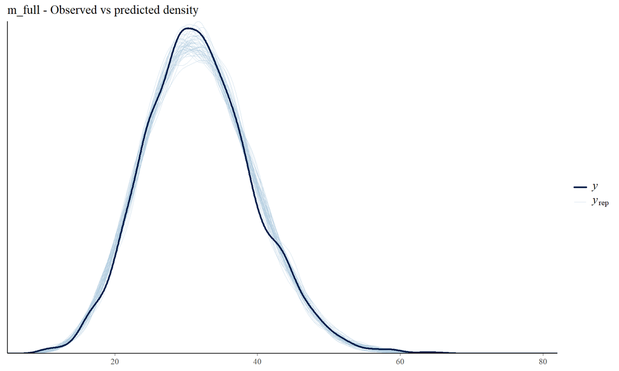

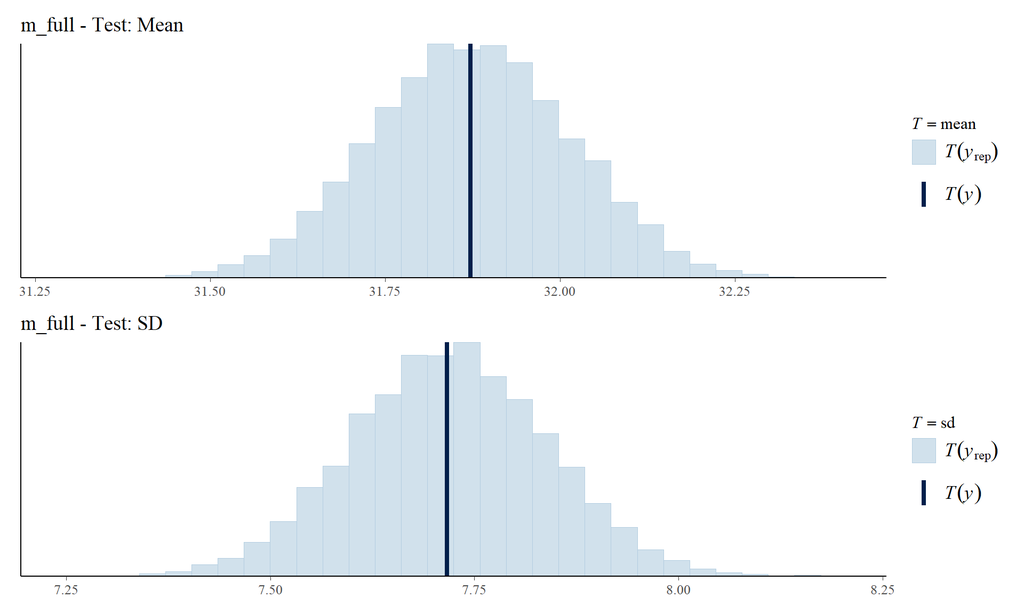

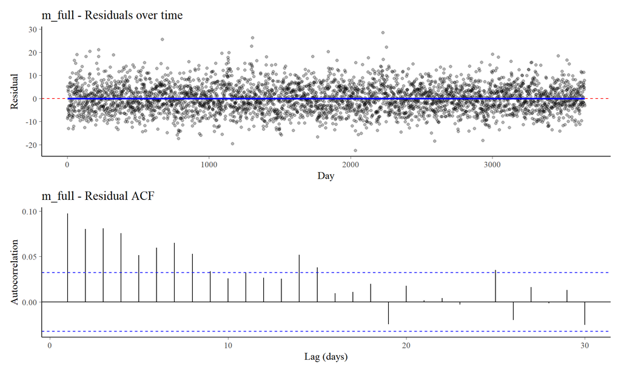

```
##
## ✓ Diagnostics completed for m_full
```

```r
loo_m_full <- loo(m_full)
print(loo_m_full)
```

```
##
## Computed from 10000 by 3646 log-likelihood matrix.
##
##          Estimate   SE
## elpd_loo -11703.2 45.2
## p_loo        48.4  1.6
## looic     23406.4 90.4
## ------
## MCSE of elpd_loo is 0.1.
## MCSE and ESS estimates assume MCMC draws (r_eff in [0.5, 1.4]).
##
## All Pareto k estimates are good (k < 0.7).
## See help('pareto-k-diagnostic') for details.
```

# 10 Model Comparison

```r
cat("\n========================================\n")
cat("   MODEL COMPARISON (LOO-CV)\n")
```

```
##    MODEL COMPARISON (LOO-CV)
```

```r
cat("========================================\n\n")
loo_comparison <- loo_compare(loo_m0_nb, loo_m_temp, loo_m_poll_linear, loo_m_full)
print(loo_comparison)
```

```
##               elpd_diff se_diff
## m_poll_linear    0.0       0.0
## m_full          -1.9       1.8
## m_temp         -98.1      10.1
## m0_nb         -381.1      33.1
```

```r
cat("\n=== MODEL COMPARISON INTERPRETATION ===\n\n")
```

```
##
## === MODEL COMPARISON INTERPRETATION ===
```